# eda_proj2

YZ

3/12/2020

## Exploratory Analysis

### Observations:

#### Load in the bank-additional-full.csv dataset

#### A total of 21 columns

```r
# Yang EDA
summary(bank)
```

```
##       age            job              marital           education
##  Min.   :17.00   Length:41188       Length:41188       Length:41188
##  1st Qu.:32.00   Class :character   Class :character   Class :character
##  Median :38.00   Mode  :character   Mode  :character   Mode  :character
##  Mean   :40.02
##  3rd Qu.:47.00
##  Max.   :98.00
##    default            housing              loan             contact
##  Length:41188       Length:41188       Length:41188       Length:41188
##  Class :character   Class :character   Class :character   Class :character
##  Mode  :character   Mode  :character   Mode  :character   Mode  :character
##
##
##
##     month           day_of_week           duration         campaign
##  Length:41188       Length:41188       Min.   :   0.0   Min.   : 1.000
##  Class :character   Class :character   1st Qu.: 102.0   1st Qu.: 1.000
##  Mode  :character   Mode  :character   Median : 180.0   Median : 2.000
##                                        Mean   : 258.3   Mean   : 2.568
##                                        3rd Qu.: 319.0   3rd Qu.: 3.000
##                                        Max.   :4918.0   Max.   :56.000
##      pdays          previous       poutcome          emp.var.rate
##  Min.   :  0.0   Min.   :0.000   Length:41188       Min.   :-3.40000
##  1st Qu.:999.0   1st Qu.:0.000   Class :character   1st Qu.:-1.80000
##  Median :999.0   Median :0.000   Mode  :character   Median : 1.10000
##  Mean   :962.5   Mean   :0.173                      Mean   : 0.08189
##  3rd Qu.:999.0   3rd Qu.:0.000                      3rd Qu.: 1.40000
##  Max.   :999.0   Max.   :7.000                      Max.   : 1.40000
##  cons.price.idx  cons.conf.idx     euribor3m      nr.employed
##  Min.   :92.20   Min.   :-50.8   Min.   :0.634   Min.   :4964
##  1st Qu.:93.08   1st Qu.:-42.7   1st Qu.:1.344   1st Qu.:5099
##  Median :93.75   Median :-41.8   Median :4.857   Median :5191
##  Mean   :93.58   Mean   :-40.5   Mean   :3.621   Mean   :5167
##  3rd Qu.:93.99   3rd Qu.:-36.4   3rd Qu.:4.961   3rd Qu.:5228
##  Max.   :94.77   Max.   :-26.9   Max.   :5.045   Max.   :5228
##       y
##  Length:41188
##  Class :character
##  Mode  :character
##
##
##
```

```r
unique(bank$job)
```

```
##  [1] "housemaid"     "services"      "admin."        "blue-collar"
##  [5] "technician"    "retired"       "management"    "unemployed"
##  [9] "self-employed" "unknown"       "entrepreneur"  "student"
```

```r
unique(bank$marital)
```

```
## [1] "married"  "single"   "divorced" "unknown"
```

```r
unique(bank$education)
```

```
## [1] "basic.4y"            "high.school"         "basic.6y"
## [4] "basic.9y"            "professional.course" "unknown"
## [7] "university.degree"   "illiterate"
```

```r
unique(bank$default)
```

```
## [1] "no"      "unknown" "yes"
```

```r
unique(bank$housing)
```

```
## [1] "no"      "yes"     "unknown"
```

```r
unique(bank$loan)
```

```
## [1] "no"      "yes"     "unknown"
```

```r
unique(bank$contact)
```

```
## [1] "telephone" "cellular"
```

```r
unique(bank$month)
```

```
##  [1] "may" "jun" "jul" "aug" "oct" "nov" "dec" "mar" "apr" "sep"
```

```r
unique(bank$poutcome)
```

```
## [1] "nonexistent" "failure"     "success"
```

```r
unique(bank$y)
```

```
## [1] "no"  "yes"
```

### Observations:

#### Category variables include: job, marital, education, default, housing, loan, contact, month, day_of_week, poutcome, y

#### Continues variables include: age, duration, campaign, pdays, previous, emp.var.rate, cons.price.idx, cons.conf.idx, euribor3m, nr.employed

#### No NAs within the dataset

```r
library(GGally)
library(forcats)
library(dplyr)
#data dimensions
dim(bank)
```

```
## [1] 41188    21
```

```r
#str(reports[,c(1:10,23)])

# Print out a summary of the dataset
bank %>% glimpse()
```

```
## Observations: 41,188
## Variables: 21
## $ age            <dbl> 56, 57, 37, 40, 56, 45, 59, 41, 24, 25, 41, 25, 29, ...
## $ job            <chr> "housemaid", "services", "services", "admin.", "serv...
## $ marital        <chr> "married", "married", "married", "married", "married...
## $ education      <chr> "basic.4y", "high.school", "high.school", "basic.6y"...
## $ default        <chr> "no", "unknown", "no", "no", "no", "unknown", "no", ...
## $ housing        <chr> "no", "no", "yes", "no", "no", "no", "no", "no", "ye...
## $ loan           <chr> "no", "no", "no", "no", "yes", "no", "no", "no", "no...
## $ contact        <chr> "telephone", "telephone", "telephone", "telephone", ...
## $ month          <chr> "may", "may", "may", "may", "may", "may", "may", "ma...
## $ day_of_week    <chr> "mon", "mon", "mon", "mon", "mon", "mon", "mon", "mo...
## $ duration       <dbl> 261, 149, 226, 151, 307, 198, 139, 217, 380, 50, 55,...
## $ campaign       <dbl> 1, 1, 1, 1, 1, 1, 1, 1, 1, 1, 1, 1, 1, 1, 1, 1, 1, 1...
## $ pdays          <dbl> 999, 999, 999, 999, 999, 999, 999, 999, 999, 999, 99...
## $ previous       <dbl> 0, 0, 0, 0, 0, 0, 0, 0, 0, 0, 0, 0, 0, 0, 0, 0, 0, 0...
## $ poutcome       <chr> "nonexistent", "nonexistent", "nonexistent", "nonexi...
## $ emp.var.rate   <dbl> 1.1, 1.1, 1.1, 1.1, 1.1, 1.1, 1.1, 1.1, 1.1, 1.1, 1....
## $ cons.price.idx <dbl> 93.994, 93.994, 93.994, 93.994, 93.994, 93.994, 93.9...
## $ cons.conf.idx  <dbl> -36.4, -36.4, -36.4, -36.4, -36.4, -36.4, -36.4, -36...
## $ euribor3m      <dbl> 4.857, 4.857, 4.857, 4.857, 4.857, 4.857, 4.857, 4.8...
## $ nr.employed    <dbl> 5191, 5191, 5191, 5191, 5191, 5191, 5191, 5191, 5191...
## $ y              <chr> "no", "no", "no", "no", "no", "no", "no", "no", "no"...
```

```r
#Check NA values
print(colSums(is.na(bank)))
```

```
##            age            job        marital      education        default
##              0              0              0              0              0
##        housing           loan        contact          month    day_of_week
##              0              0              0              0              0
##       duration       campaign          pdays       previous       poutcome
##              0              0              0              0              0
##   emp.var.rate cons.price.idx  cons.conf.idx      euribor3m    nr.employed
##              0              0              0              0              0
##              y
##              0
```

### Observations:

#### The rest variables are quite discrete from their distribution.

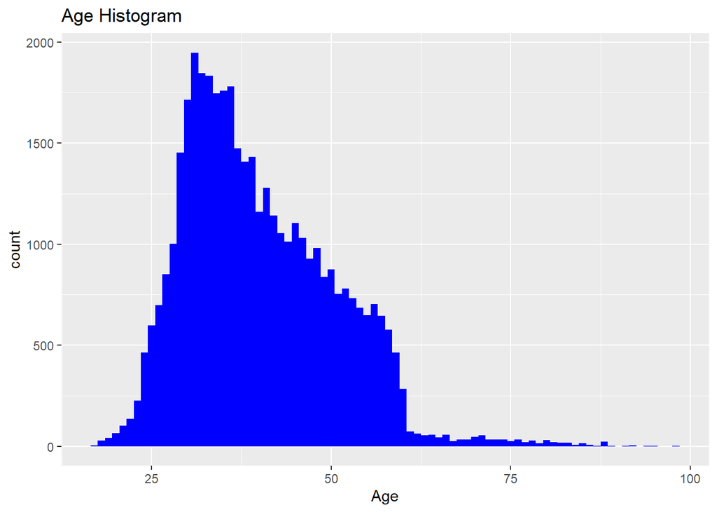

```r
ggplot(data=bank[!is.na(bank$age),], aes(x=age)) +
        geom_histogram(fill="blue", binwidth = 1) + labs(title="Age Histogram", x="Age")
```

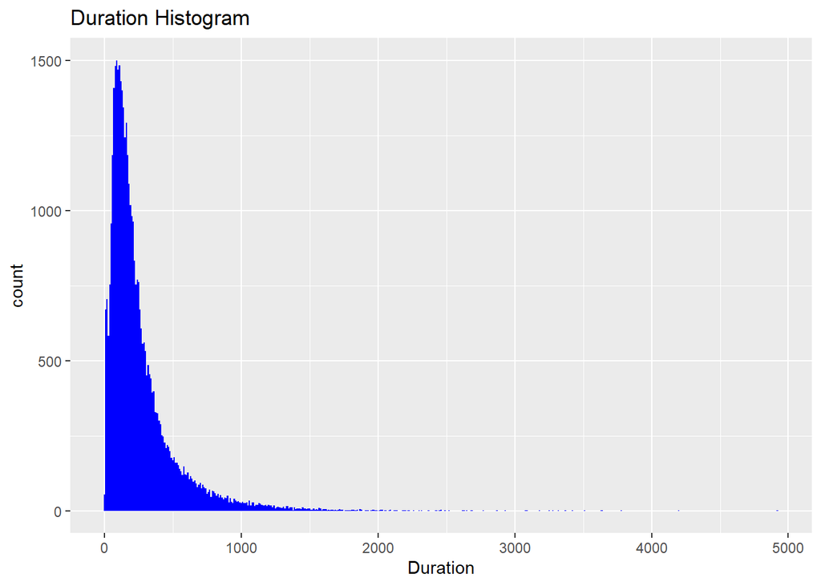

```r
ggplot(data=bank[!is.na(bank$duration),], aes(x=duration)) +
        geom_histogram(fill="blue", binwidth = 10) + labs(title="Duration Histogram", x="Duration")
```

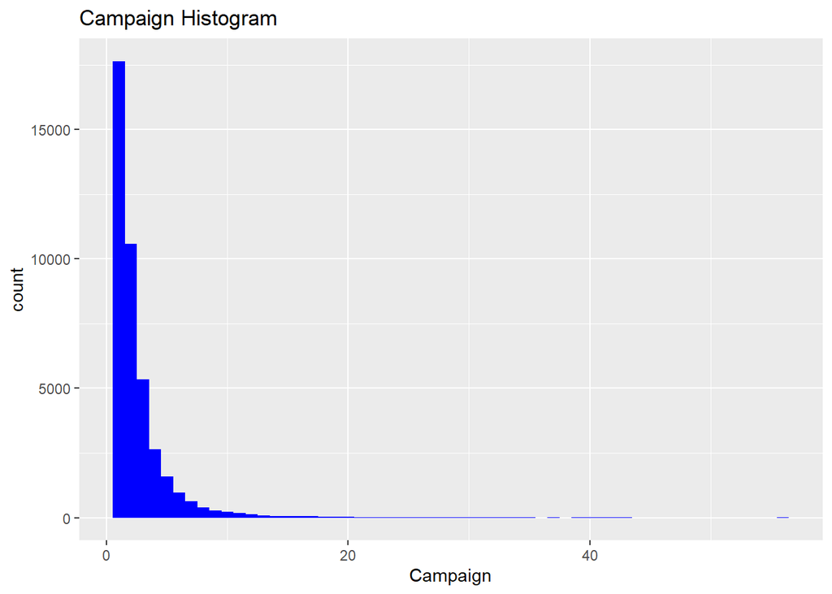

```r
ggplot(data=bank[!is.na(bank$campaign),], aes(x=campaign)) +
        geom_histogram(fill="blue", binwidth = 1) + labs(title="Campaign Histogram", x="Campaign")
```

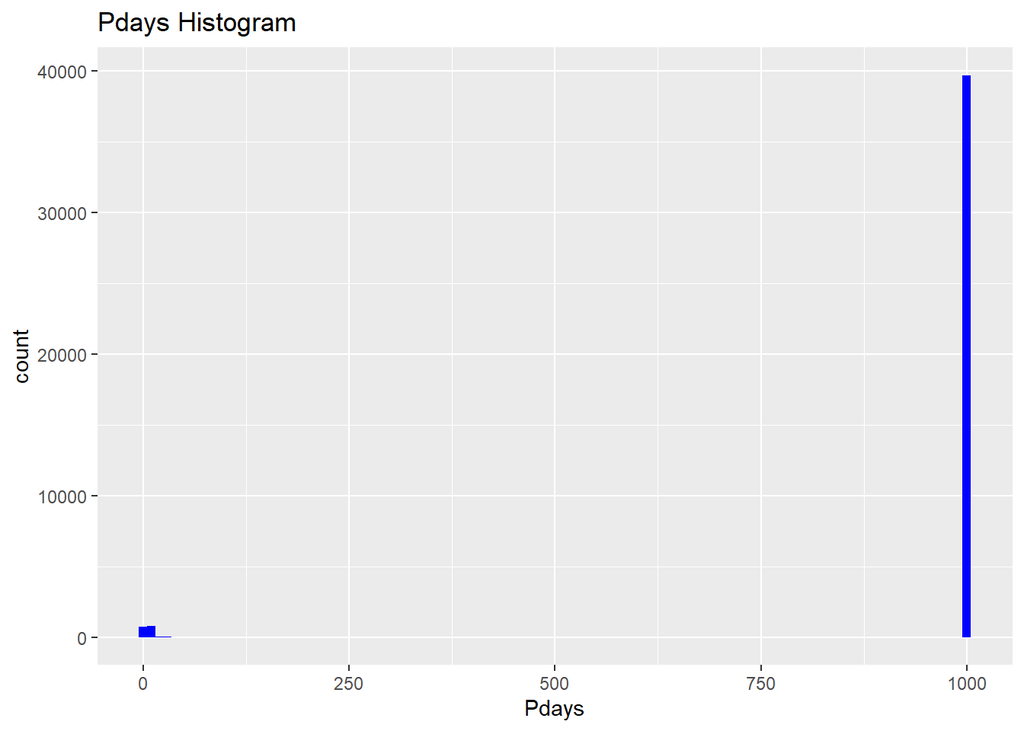

```r
ggplot(data=bank[!is.na(bank$pdays),], aes(x=pdays)) +
        geom_histogram(fill="blue", binwidth = 10) + labs(title="Pdays Histogram", x="Pdays")
```

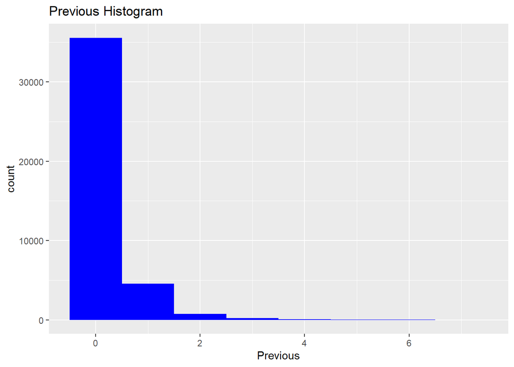

```r
ggplot(data=bank[!is.na(bank$previous),], aes(x=previous)) +
        geom_histogram(fill="blue", binwidth = 1) + labs(title="Previous Histogram", x="Previous")
```

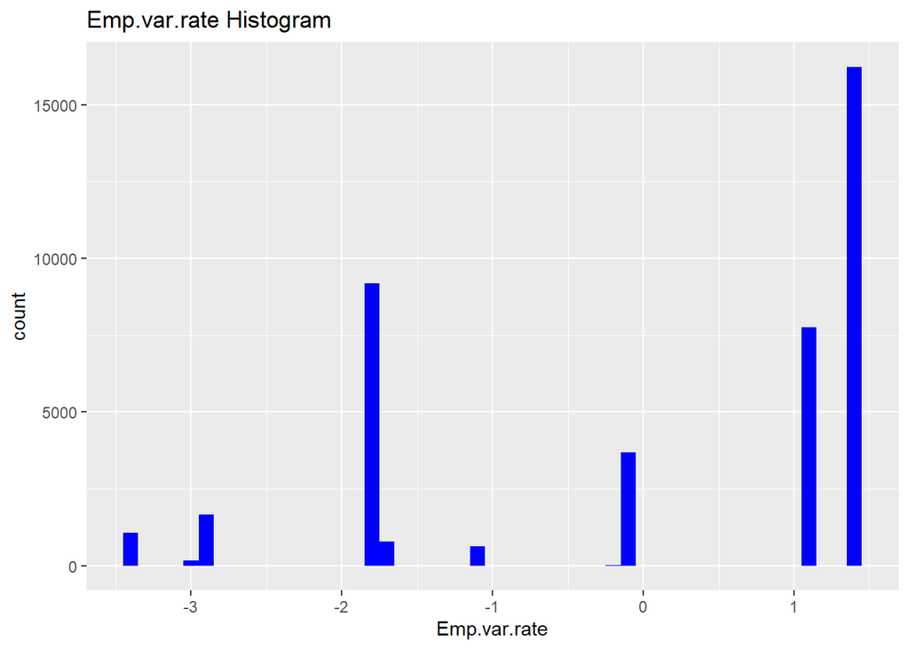

```r
ggplot(data=bank[!is.na(bank$emp.var.rate),], aes(x=emp.var.rate)) +
        geom_histogram(fill="blue", binwidth = 0.1) + labs(title="Emp.var.rate Histogram", x="Emp.var.rate")
```

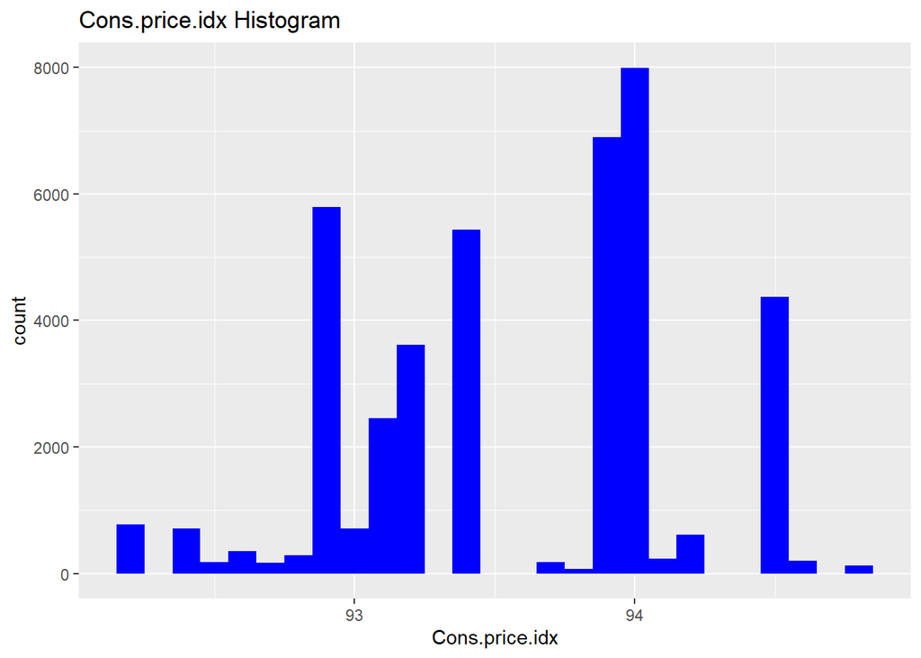

```r
ggplot(data=bank[!is.na(bank$cons.price.idx),], aes(x=cons.price.idx)) +
        geom_histogram(fill="blue", binwidth = 0.1) + labs(title="Cons.price.idx Histogram", x="Cons.price.idx")
```

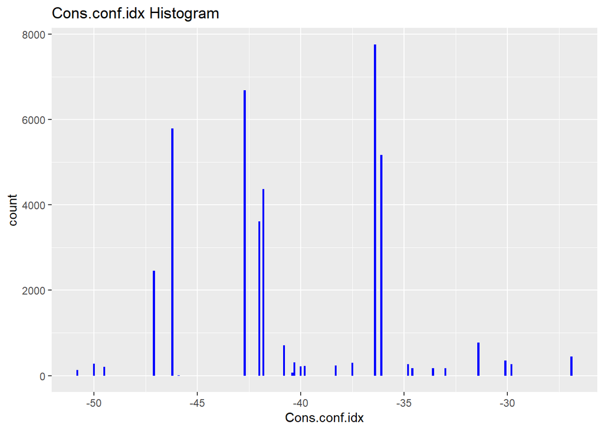

```r
ggplot(data=bank[!is.na(bank$cons.conf.idx),], aes(x=cons.conf.idx)) +
        geom_histogram(fill="blue", binwidth = 0.1) + labs(title="Cons.conf.idx Histogram", x="Cons.conf.idx")
```

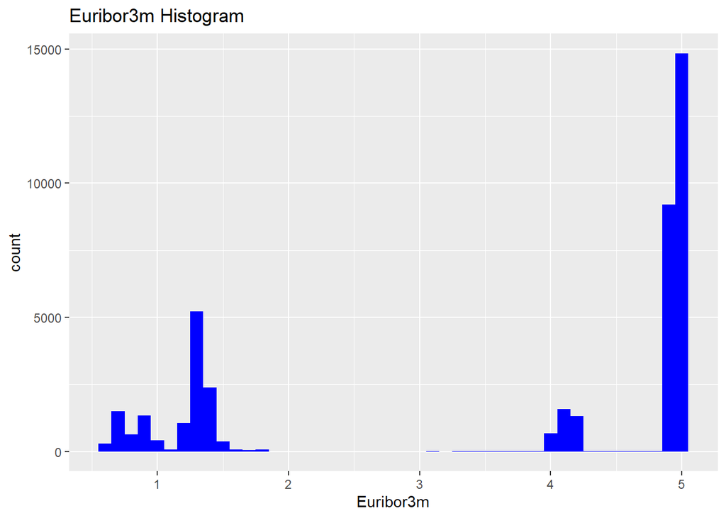

```r
ggplot(data=bank[!is.na(bank$euribor3m),], aes(x=euribor3m)) +
        geom_histogram(fill="blue", binwidth = 0.1) + labs(title="Euribor3m Histogram", x="Euribor3m")
```

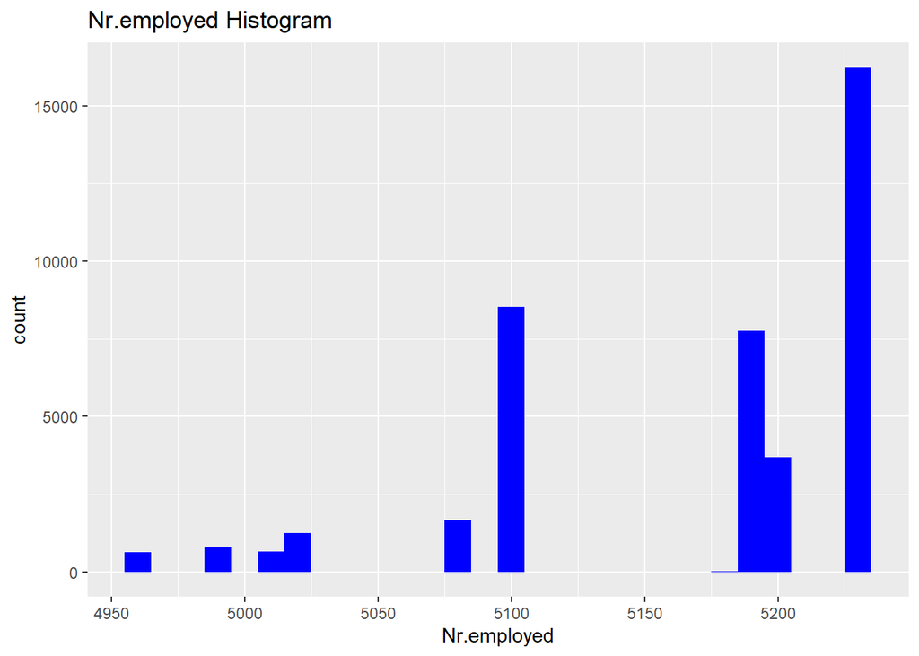

```r
ggplot(data=bank[!is.na(bank$nr.employed),], aes(x=nr.employed)) +
        geom_histogram(fill="blue", binwidth = 10) + labs(title="Nr.employed Histogram", x="Nr.employed")
```

### Observations:

#### Continuous variables are plotted by contrasting y, some show obvious differences some don’t.

#### Some variables the showed differences: Duration, Emp.var.rate, Cons.price,idx, Ons.conf.idx, Euribor3m, Nr.employed

#### Some variables don’t show obvious differences:Age, Campaign, Previous

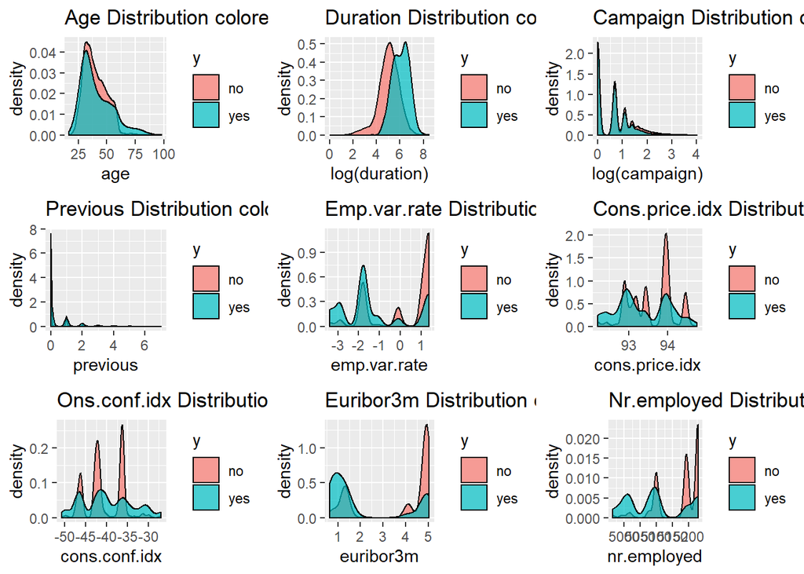

```r
g1<- bank %>% ggplot(aes(x=age, fill=y)) + geom_density(alpha = 0.7) + labs(title="Age Distribution colored by Term Deposit")

g2<- bank %>% ggplot(aes(x=log(duration), fill=y)) + geom_density(alpha = 0.7) + labs(title="Duration Distribution colored by Term Deposit")

g3<- bank %>% ggplot(aes(x=log(campaign), fill=y)) + geom_density(alpha = 0.7) + labs(title="Campaign Distribution colored by Term Deposit")

g4<- bank %>% ggplot(aes(x=previous, fill=y)) + geom_density(alpha = 0.7) + labs(title="Previous Distribution colored by Term Deposit")

g5<- bank %>% ggplot(aes(x=emp.var.rate, fill=y)) + geom_density(alpha = 0.7) + labs(title="Emp.var.rate Distribution colored by Term Deposit")

g6<- bank %>% ggplot(aes(x=cons.price.idx, fill=y)) + geom_density(alpha = 0.7) + labs(title="Cons.price.idx Distribution colored by Term Deposit")

g7<- bank %>% ggplot(aes(x=cons.conf.idx, fill=y)) + geom_density(alpha = 0.7) + labs(title="Ons.conf.idx Distribution colored by Term Deposit")

g8<- bank %>% ggplot(aes(x=euribor3m, fill=y)) + geom_density(alpha = 0.7) + labs(title="Euribor3m Distribution colored by Term Deposit")

g9<- bank %>% ggplot(aes(x=nr.employed, fill=y)) + geom_density(alpha = 0.7) + labs(title="Nr.employed Distribution colored by Term Deposit")

grid.arrange(g1,g2,g3,g4,g5,g6,g7,g8,g9,ncol = 3, nrow = 3)
```

### Observations:

#### We observed some seperation in cross-plot colored by variable y.

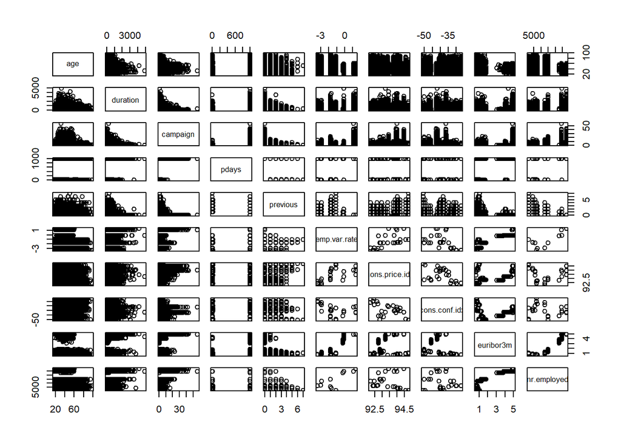

```r
bank_con <- bank %>% dplyr::select(age, duration,campaign,pdays,previous,emp.var.rate,cons.price.idx,cons.conf.idx,euribor3m,nr.employed)

pairs(bank_con)
```

```r
table(bank$y)
```

```
##
##    no   yes
## 36548  4640
```

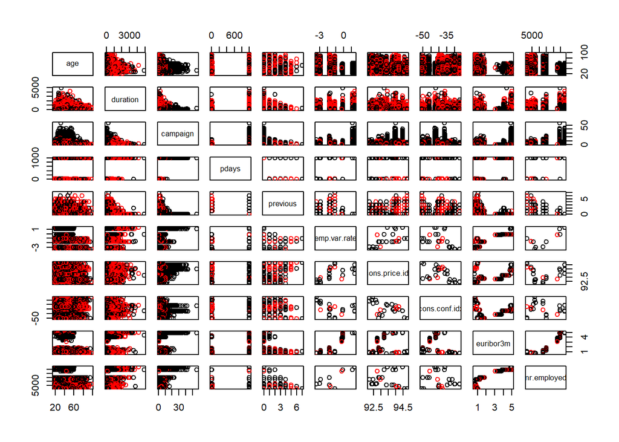

```r
bank_cony <- bank %>% dplyr::select(age, duration,campaign,pdays,previous,emp.var.rate,cons.price.idx,cons.conf.idx,euribor3m,nr.employed,y)

bank_cony$y <- factor(bank_cony$y)

pairs(bank_cony[,-11], col=bank_cony$y)
```

### Observations:

#### Crossplots of some continuous variables to identify the seperation by variable y. Age vs Duration shows seperation in duration. Campaign vs Duration also shows seperation in duration.

#### Other crossplots doesn’t show obvious seperation by variable y.

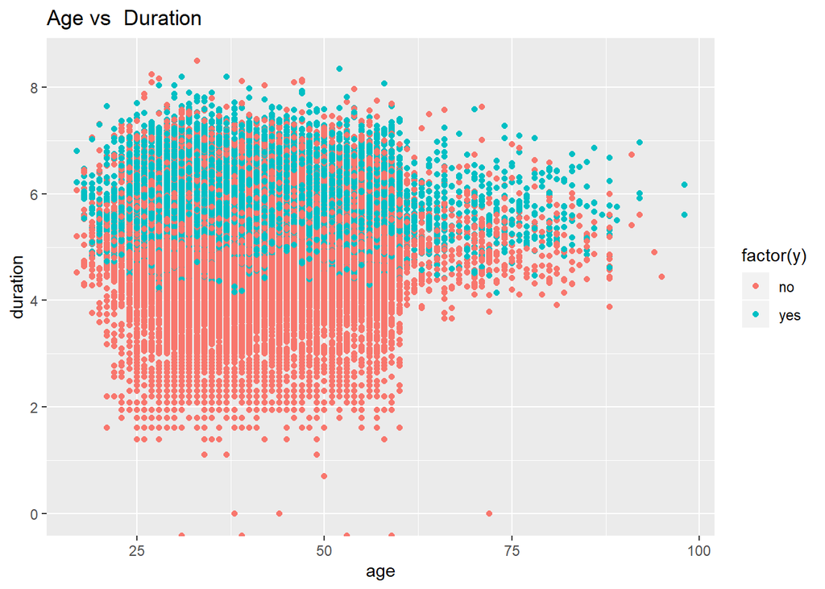

```r
bank %>% dplyr::select(age, duration,y) %>%
ggplot(aes(x=age, y=log(duration)))+ geom_point(aes(colour = factor(y))) + labs(title="Age vs  Duration", x="age",y="duration")
```

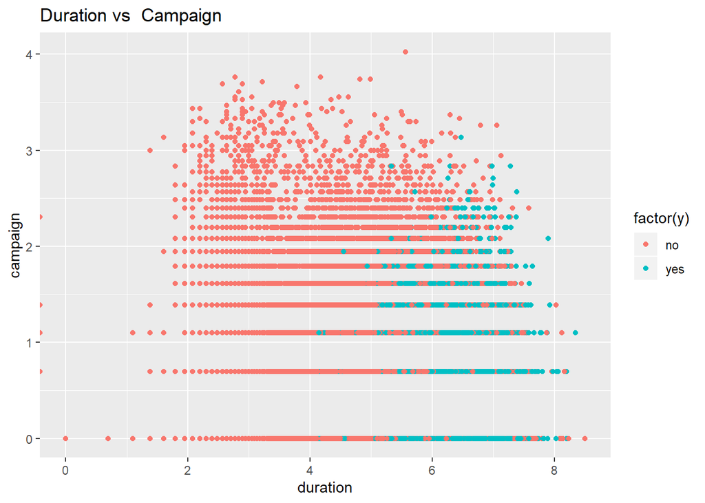

```r
bank %>% dplyr::select(duration,campaign,y) %>%
ggplot(aes(x=log(duration), y=log(campaign)))+ geom_point(aes(colour = factor(y))) + labs(title="Duration vs  Campaign", x="duration",y="campaign")
```

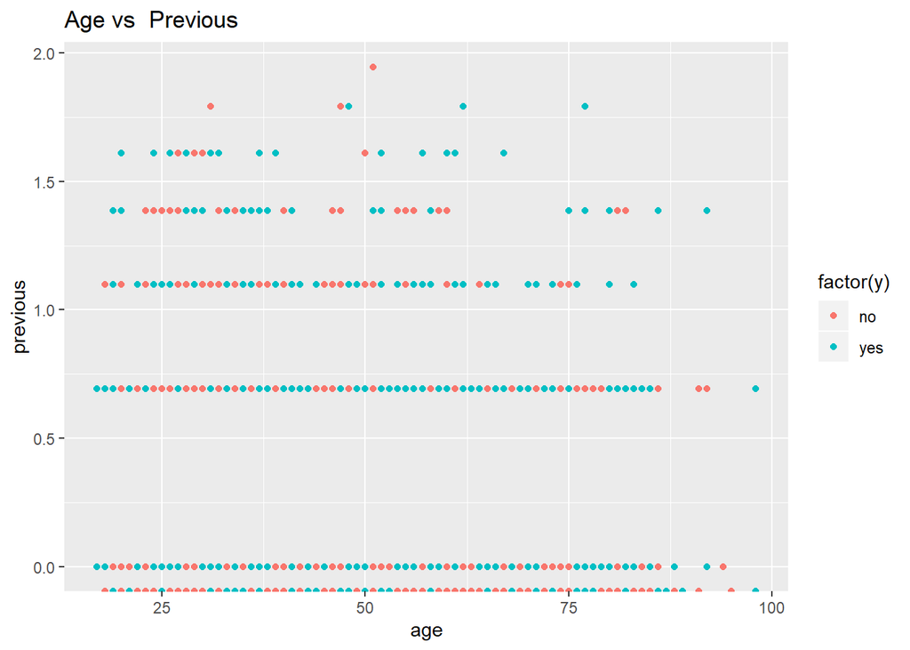

```r
bank %>% dplyr::select(age, previous,y) %>%
ggplot(aes(x=age, y=log(previous)))+ geom_point(aes(colour = factor(y))) + labs(title="Age vs  Previous", x="age",y="previous")
```

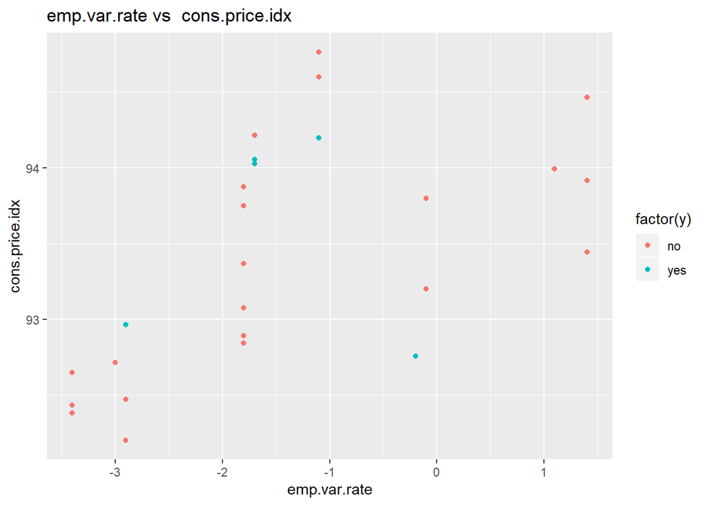

```r
bank %>% dplyr::select(emp.var.rate, cons.price.idx,y) %>%
ggplot(aes(x=emp.var.rate, y=cons.price.idx))+ geom_point(aes(colour = factor(y))) + labs(title="emp.var.rate vs  cons.price.idx", x="emp.var.rate",y="cons.price.idx")
```

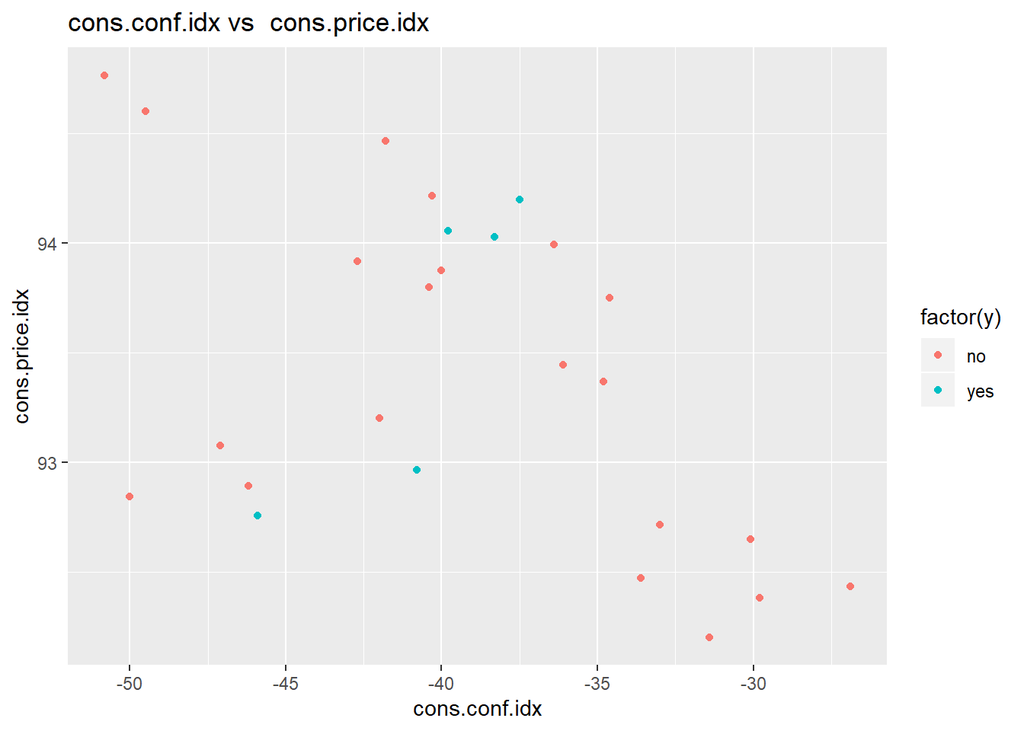

```r
bank %>% dplyr::select(cons.conf.idx, cons.price.idx,y) %>%
ggplot(aes(x=cons.conf.idx, y=cons.price.idx))+ geom_point(aes(colour = factor(y))) + labs(title="cons.conf.idx vs  cons.price.idx", x="cons.conf.idx",y="cons.price.idx")
```

### Observations:

#### We did pca on the continous data group. Good seperation on especially PC2.

#### PC1 is a combination of emp.var.rate,cons.price.idx,euribor3m,nr.employed.

#### PC2 is a combination of pdays and previous.

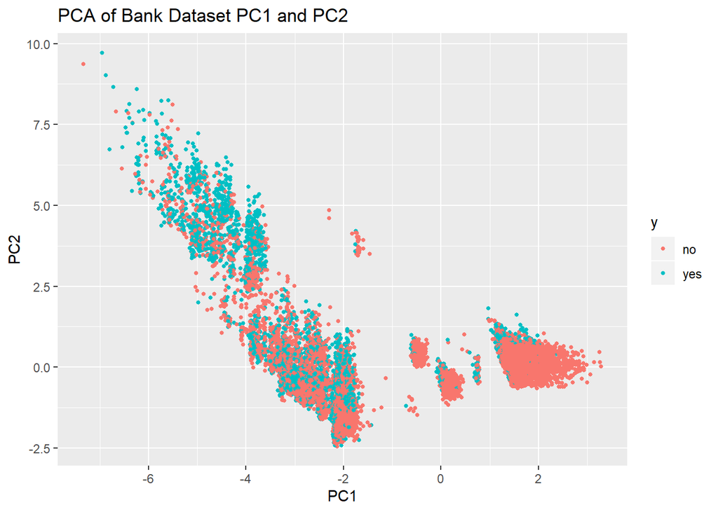

```r
pc.bc<-prcomp(bank_con,scale.=TRUE)
pc.bc.scores<-pc.bc$x

#Adding the response column to the PC's data frame
pc.bc.scores<-data.frame(pc.bc.scores)
pc.bc.scores$y<-bank$y

#Use ggplot2 to plot the first few pc's
library(ggplot2)
ggplot(data = pc.bc.scores, aes(x = PC1, y = PC2)) +
  geom_point(aes(col=y), size=1)+
  ggtitle("PCA of Bank Dataset PC1 and PC2")
```

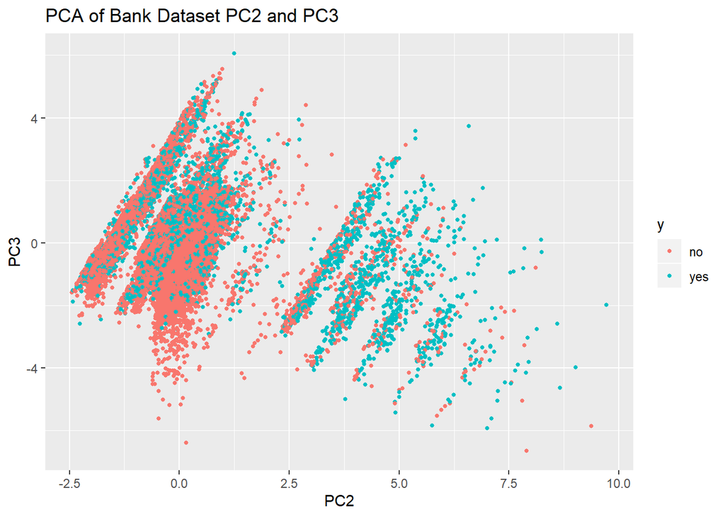

```r
ggplot(data = pc.bc.scores, aes(x = PC2, y = PC3)) +
  geom_point(aes(col=y), size=1)+
  ggtitle("PCA of Bank Dataset PC2 and PC3")
```

```r
pc.bc$rotation
```

```
##                         PC1          PC2          PC3          PC4         PC5
## age            -0.001577131  0.251900655  0.635282811 -0.253370761  0.44501766
## duration       -0.025564414  0.081409042  0.040921453  0.767885976  0.59089472
## campaign        0.100490892 -0.007934948 -0.324028903 -0.575546022  0.61975410
## pdays           0.227536614 -0.628711981  0.252674001 -0.006719777  0.05446567
## previous       -0.305815059  0.474453454 -0.281754824 -0.021267326 -0.03416913
## emp.var.rate    0.488002497  0.163001272 -0.091015114  0.044439336 -0.03068934
## cons.price.idx  0.366097505  0.279060437 -0.276172371  0.073400593  0.04059256
## cons.conf.idx   0.101572714  0.427668539  0.510937020 -0.070490333 -0.23898992
## euribor3m       0.490377105  0.148132110 -0.002732445  0.036446035 -0.06312538
## nr.employed     0.470094939 -0.013534619 -0.029958110  0.027276466 -0.02971432
##                         PC6         PC7          PC8           PC9
## age            -0.519053816  0.03130209 -0.017883104  1.877379e-03
## duration        0.222453386  0.03759640  0.036557378 -1.291328e-03
## campaign        0.411271670  0.00457756  0.015618439  1.144203e-05
## pdays           0.017271037 -0.22220217  0.660616627  2.347902e-03
## previous       -0.146373752  0.19252528  0.735882396 -1.826083e-02
## emp.var.rate   -0.075546254  0.07039768  0.047342403  7.938804e-01
## cons.price.idx -0.249851072 -0.73172135  0.003923396 -3.114171e-01
## cons.conf.idx   0.647573823 -0.17299928  0.120583312 -7.079644e-02
## euribor3m       0.004006082  0.21662283  0.052635324 -6.342829e-02
## nr.employed    -0.052239619  0.54214369  0.024394248 -5.132191e-01
##                         PC10
## age             0.0013597361
## duration        0.0013824218
## campaign       -0.0092865724
## pdays           0.0007657793
## previous        0.0042240094
## emp.var.rate    0.2844876703
## cons.price.idx  0.0997677428
## cons.conf.idx   0.1216873967
## euribor3m      -0.8237302095
## nr.employed     0.4643979470
```

#### PCA results shows 7 PCs can explain 95% of the variations

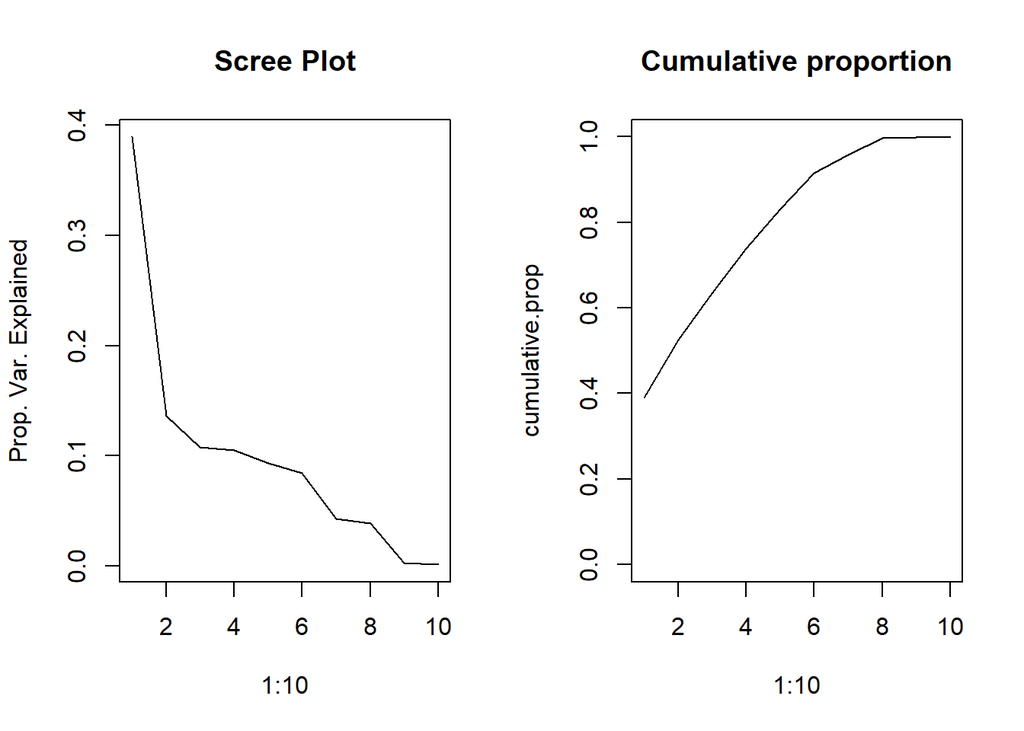

```r
par(mfrow=c(1,2))
eigenvals<-(pc.bc$sdev)^2
plot(1:10,eigenvals/sum(eigenvals),type="l",main="Scree Plot",ylab="Prop. Var. Explained")
cumulative.prop<-cumsum(eigenvals/sum(eigenvals))
plot(1:10,cumulative.prop,type="l",main="Cumulative proportion",ylim=c(0,1))
```

```r
cumulative.prop
```

```
##  [1] 0.3895496 0.5254379 0.6332024 0.7382385 0.8311838 0.9153671 0.9578786
##  [8] 0.9964507 0.9989396 1.0000000
```

### Observations:

#### Because pdays is not a typical continous feature, we did pca on the continous data group excluding this variable. Good seperation on PC2 and PC3

#### PC2 is a combination of age and cons.conf.idx.

#### PC3 is a combination of duration and campaign.

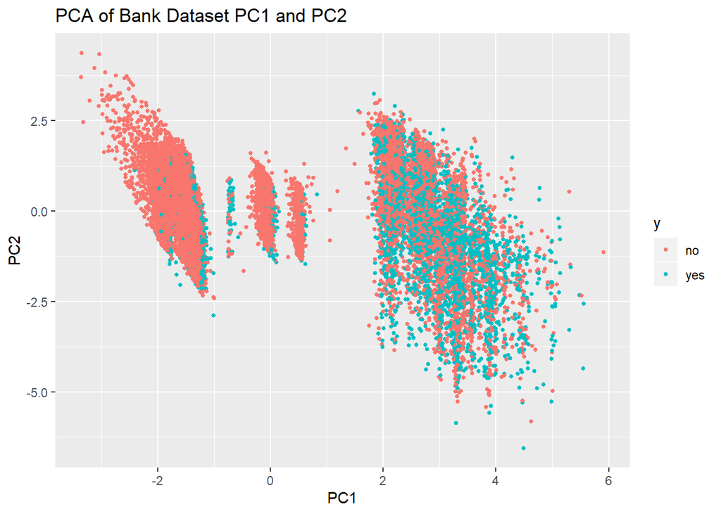

```r
bank_con2 <- bank %>% dplyr::select(age, duration,campaign,previous,emp.var.rate,cons.price.idx,cons.conf.idx,euribor3m,nr.employed)

pc.bc2<-prcomp(bank_con2,scale.=TRUE)
pc.bc2.scores<-pc.bc2$x

#Adding the response column to the PC's data frame
pc.bc2.scores<-data.frame(pc.bc2.scores)
pc.bc2.scores$y<-bank$y

#Use ggplot2 to plot the first few pc's
library(ggplot2)
ggplot(data = pc.bc2.scores, aes(x = PC1, y = PC2)) +
  geom_point(aes(col=y), size=1)+
  ggtitle("PCA of Bank Dataset PC1 and PC2")
```

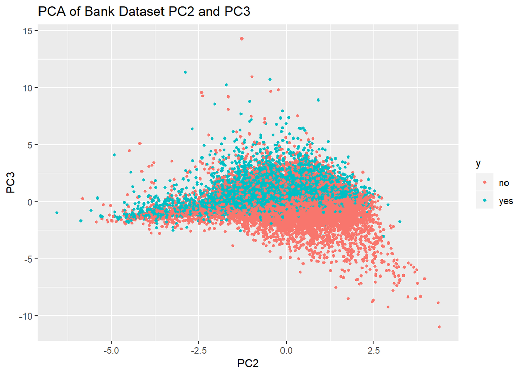

```r
ggplot(data = pc.bc2.scores, aes(x = PC2, y = PC3)) +
  geom_point(aes(col=y), size=1)+
  ggtitle("PCA of Bank Dataset PC2 and PC3")
```

```r
pc.bc2$rotation
```

```
##                         PC1          PC2         PC3         PC4         PC5
## age            -0.002200473 -0.675172012 -0.24107066  0.33472783 -0.59783121
## duration        0.023511619 -0.101543696  0.76747028  0.58512010  0.08805055
## campaign       -0.104365986  0.228144944 -0.58311533  0.65960228  0.28790200
## previous        0.283449321 -0.128859806 -0.03114957  0.17431889  0.42129622
## emp.var.rate   -0.506260737 -0.003945537  0.04176716  0.01017802  0.03314032
## cons.price.idx -0.389916180  0.045812111  0.06554395  0.15888076  0.08911596
## cons.conf.idx  -0.118394205 -0.674199390 -0.06173760 -0.22403611  0.59277493
## euribor3m      -0.506832510 -0.060465241  0.03588990 -0.04433503  0.04599542
## nr.employed    -0.478513995  0.069724361  0.02721029 -0.05123530 -0.10922108
##                        PC6          PC7           PC8          PC9
## age             0.12688492 -0.021744621 -1.876063e-03  0.001358742
## duration       -0.21858221 -0.047171296  1.361731e-03  0.001359751
## campaign       -0.28086806 -0.009912242 -1.481802e-07 -0.009289771
## previous        0.71108159 -0.433786312  1.953447e-02  0.003816788
## emp.var.rate    0.14964046 -0.084310227 -7.939344e-01  0.284439619
## cons.price.idx  0.48305324  0.684055453  3.117302e-01  0.099688652
## cons.conf.idx  -0.30230774  0.121741040  7.112232e-02  0.121585089
## euribor3m       0.04285009 -0.223091601  6.339318e-02 -0.823693399
## nr.employed    -0.05137459 -0.519039885  5.128630e-01  0.464540594
```

#### PCA results shows 6 PCs can explain 95% of the variations

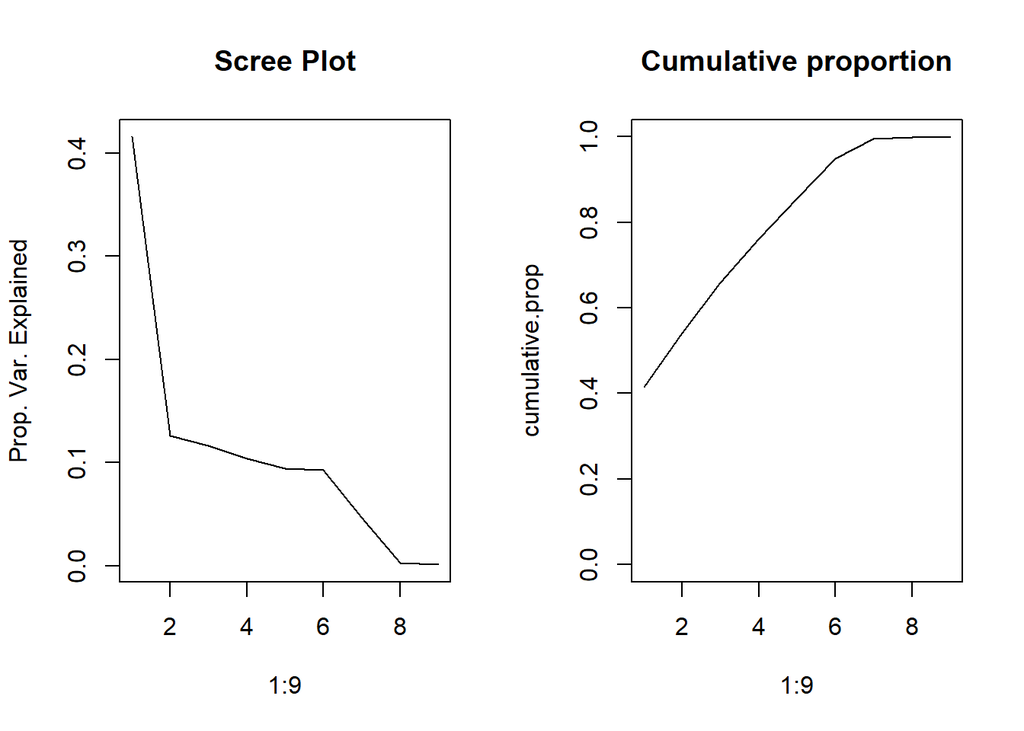

```r
par(mfrow=c(1,2))
eigenvals<-(pc.bc2$sdev)^2
plot(1:9,eigenvals/sum(eigenvals),type="l",main="Scree Plot",ylab="Prop. Var. Explained")
cumulative.prop<-cumsum(eigenvals/sum(eigenvals))
plot(1:9,cumulative.prop,type="l",main="Cumulative proportion",ylim=c(0,1))
```

```r
cumulative.prop
```

```
## [1] 0.4157118 0.5418104 0.6585189 0.7624433 0.8566982 0.9492839 0.9960559
## [8] 0.9988217 1.0000000
```

### Observations:

#### LDA with all exist continuous variables can get an accuracy of 90.7%.

```r
### LDA with all continuous variables
library(MASS)
mylda1 <- lda(bank$y ~ . , data = bank_con)

x1=table(predict(mylda1, type="class")$class, bank$y)
x1
```

```
##
##          no   yes
##   no  35294  2568
##   yes  1254  2072
```

```r
#presicion
x1[1,1]/sum(x1[1,1:2])
```

```
## [1] 0.9321747
```

```r
#recall
x1[1,1]/sum(x1[1:2,1])
```

```
## [1] 0.965689
```

```r
# F score

(2*(x1[1,1]/sum(x1[1,1:2])) * (x1[1,1]/sum(x1[1:2,1])))/(x1[1,1]/sum(x1[1,1:2])) + (x1[1,1]/sum(x1[1:2,1]))
```

```
## [1] 2.897067
```

```r
#Missclassification Error
ME1<-(x1[2,1]+x1[1,2])/dim(bank_con)[1]
ME1
```

```
## [1] 0.09279402
```

```r
#Calculating overall accuracy
1-ME1
```

```
## [1] 0.907206
```

### Observations:

```r
### LDA with all continuous variables excluding pdays

mylda2 <- lda(bank$y ~ . , data = bank_con2)

x1=table(predict(mylda2, type="class")$class, bank$y)
x1
```

```
##
##          no   yes
##   no  35076  2407
##   yes  1472  2233
```

```r
#presicion
x1[1,1]/sum(x1[1,1:2])
```

```
## [1] 0.9357842
```

```r
#recall
x1[1,1]/sum(x1[1:2,1])
```

```
## [1] 0.9597242
```

```r
# F score

(2*(x1[1,1]/sum(x1[1,1:2])) * (x1[1,1]/sum(x1[1:2,1])))/(x1[1,1]/sum(x1[1,1:2])) + (x1[1,1]/sum(x1[1:2,1]))
```

```
## [1] 2.879173
```

```r
#Missclassification Error
ME1<-(x1[2,1]+x1[1,2])/dim(bank_con2)[1]
ME1
```

```
## [1] 0.09417792
```

```r
#Calculating overall accuracy
1-ME1
```

```
## [1] 0.9058221
```

### Observations:

#### LDA with selected continuous variables can get an accuracy of 90.7%.

```r
### LDA with all continuous variables selected from Balaji's work

bank_con_select = bank %>% dplyr::select(c('age', 'duration', 'campaign', 'pdays', 'previous',  'cons.price.idx', 'cons.conf.idx',
                                       'euribor3m'))


mylda3 <- lda(bank$y ~ . , data = bank_con_select)

x1=table(predict(mylda3, type="class")$class, bank$y)
x1
```

```
##
##          no   yes
##   no  35296  2565
##   yes  1252  2075
```

```r
#presicion
x1[1,1]/sum(x1[1,1:2])
```

```
## [1] 0.9322522
```

```r
#recall
x1[1,1]/sum(x1[1:2,1])
```

```
## [1] 0.9657437
```

```r
# F score

(2*(x1[1,1]/sum(x1[1,1:2])) * (x1[1,1]/sum(x1[1:2,1])))/(x1[1,1]/sum(x1[1,1:2])) + (x1[1,1]/sum(x1[1:2,1]))
```

```
## [1] 2.897231
```

```r
#Missclassification Error
ME1<-(x1[2,1]+x1[1,2])/dim(bank_con_select)[1]
ME1
```

```
## [1] 0.09267262
```

```r
#Calculating overall accuracy
1-ME1
```

```
## [1] 0.9073274
```

### Observations:

#### PCA with selected continuous variables show some good seperation in PC1 vs PC2 and PC2 vs PC3.

#### PC1 is a combination of pdays, previous, cons.price.idx and eruibor3m.

#### PC2 is a combination of pdays, cons.conf.idx.

#### PC3 is a combination of age, duration and campaign.

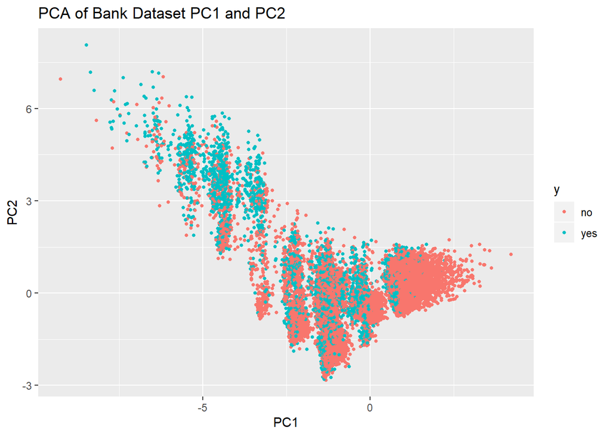

```r
pc.bc3<-prcomp(bank_con_select,scale.=TRUE)
pc.bc3.scores<-pc.bc3$x

#Adding the response column to the PC's data frame
pc.bc3.scores<-data.frame(pc.bc3.scores)
pc.bc3.scores$y<-bank$y

#Use ggplot2 to plot the first few pc's
ggplot(data = pc.bc3.scores, aes(x = PC1, y = PC2)) +
  geom_point(aes(col=y), size=1)+
  ggtitle("PCA of Bank Dataset PC1 and PC2")
```

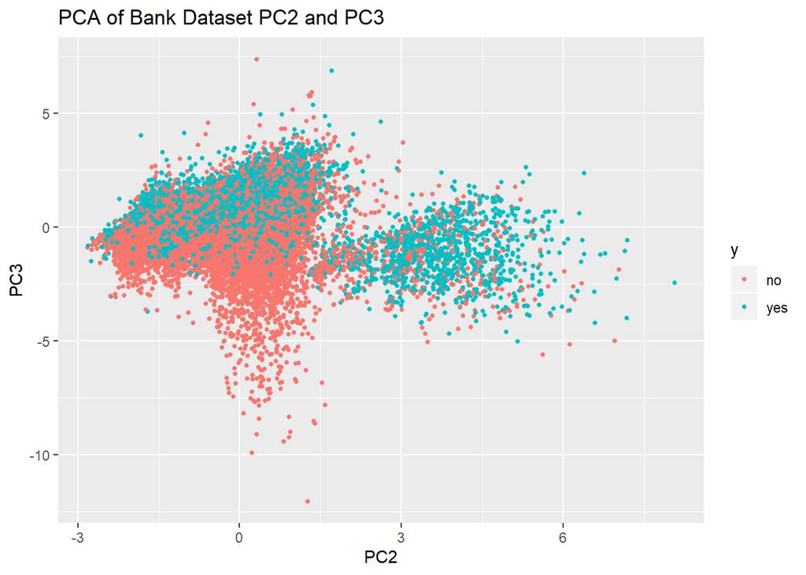

```r
ggplot(data = pc.bc3.scores, aes(x = PC2, y = PC3)) +
  geom_point(aes(col=y), size=1)+
  ggtitle("PCA of Bank Dataset PC2 and PC3")
```

```r
pc.bc3$rotation
```

```
##                          PC1         PC2         PC3         PC4         PC5
## age            -0.0001505034  0.33178443  0.40031238 -0.51674450 -0.52123186
## duration       -0.0474885396  0.05962395  0.39673295  0.69701344 -0.54351147
## campaign        0.1604099053  0.04270741 -0.61928792 -0.24008562 -0.58022864
## pdays           0.4022456061 -0.53347286  0.23490471 -0.15461570 -0.06782416
## previous       -0.4960284640  0.34620368 -0.24436495  0.09825486  0.02308755
## cons.price.idx  0.4537283085  0.34192328 -0.26667050  0.31153547  0.01515846
## cons.conf.idx   0.1414123127  0.54450723  0.33343535 -0.20993927  0.28396222
## euribor3m       0.5816363928  0.25824450 -0.04060412  0.12172678  0.10124175
##                        PC6         PC7         PC8
## age            -0.43615489  0.02071222  0.01736234
## duration        0.23248639 -0.03293873  0.02062645
## campaign        0.44081086 -0.01430100 -0.01010489
## pdays           0.03736370 -0.67527933 -0.11189551
## previous       -0.13147938 -0.71644837  0.18333682
## cons.price.idx -0.39958023 -0.09082475 -0.58387355
## cons.conf.idx   0.61395230 -0.13884757 -0.22673815
## euribor3m      -0.07823115 -0.03812210  0.74881205
```

#### PCA results shows 6 PCs can explain 92% of the variations

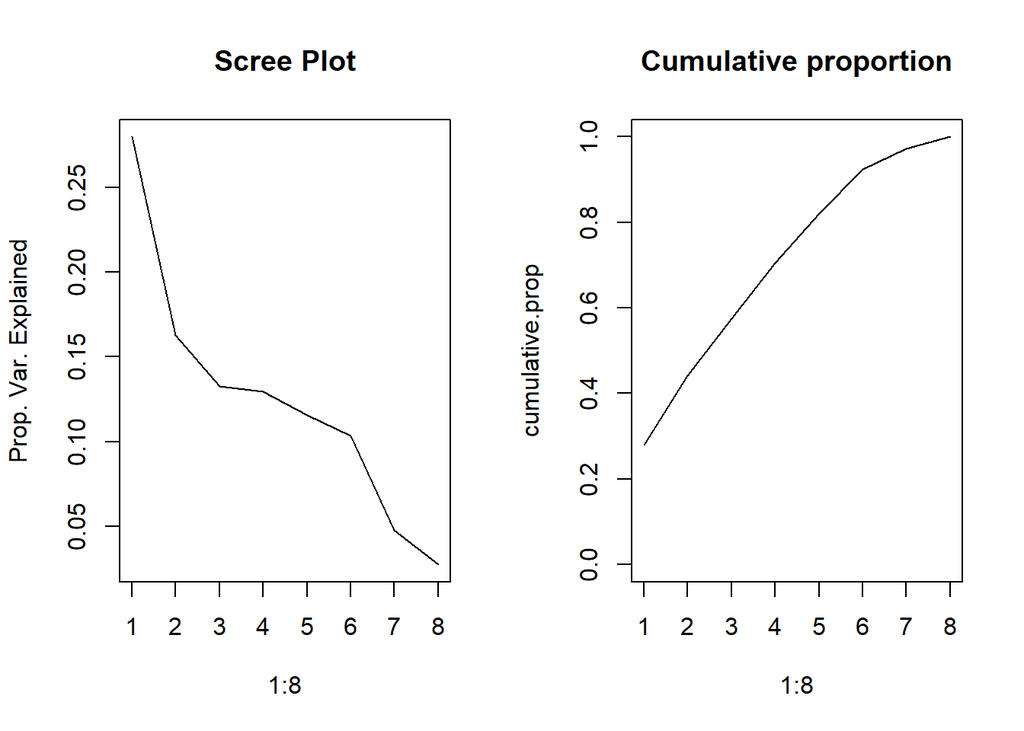

```r
par(mfrow=c(1,2))
eigenvals<-(pc.bc3$sdev)^2
plot(1:8,eigenvals/sum(eigenvals),type="l",main="Scree Plot",ylab="Prop. Var. Explained")
cumulative.prop<-cumsum(eigenvals/sum(eigenvals))
plot(1:8,cumulative.prop,type="l",main="Cumulative proportion",ylim=c(0,1))
```

```r
cumulative.prop
```

```
## [1] 0.2796591 0.4424969 0.5753833 0.7051199 0.8208777 0.9242170 0.9723551
## [8] 1.0000000
```

### LDA with 6 PCs as variables give an accuracy of 90.4%.

```r
mylda4 <- lda(bank$y ~ PC1+PC2+PC3+PC4+PC5+PC6 , data = pc.bc3.scores)

x1=table(predict(mylda4, type="class")$class, bank$y)
x1
```

```
##
##          no   yes
##   no  35253  2679
##   yes  1295  1961
```

```r
#presicion
x1[1,1]/sum(x1[1,1:2])
```

```
## [1] 0.9293736
```

```r
#recall
x1[1,1]/sum(x1[1:2,1])
```

```
## [1] 0.9645671
```

```r
# F score

(2*(x1[1,1]/sum(x1[1,1:2])) * (x1[1,1]/sum(x1[1:2,1])))/(x1[1,1]/sum(x1[1,1:2])) + (x1[1,1]/sum(x1[1:2,1]))
```

```
## [1] 2.893701
```

```r
#Missclassification Error
ME1<-(x1[2,1]+x1[1,2])/dim(bank_con_select)[1]
ME1
```

```
## [1] 0.09648441
```

```r
#Calculating overall accuracy
1-ME1
```

```
## [1] 0.9035156
```

### LDA with only the first 2 PCs as variables shows a linear cutoff line below.

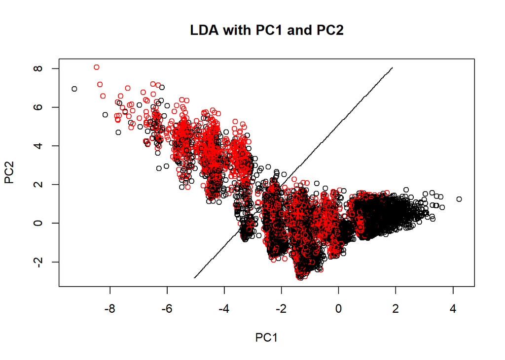

```r
# construct the LDA model
mylda5 <- lda(bank$y ~ PC1+PC2, data = pc.bc3.scores)

# draw discrimination line
np <- 300
nd.x <- seq(from = min(pc.bc3.scores$PC1), to = max(pc.bc3.scores$PC1), length.out = np)
nd.y <- seq(from = min(pc.bc3.scores$PC2), to = max(pc.bc3.scores$PC2), length.out = np)
nd <- expand.grid(PC1 = nd.x, PC2 = nd.y)

prd <- as.numeric(predict(mylda5, newdata = nd)$class)

plot(pc.bc3.scores[, 1:2], col = as.factor(bank$y), main="LDA with PC1 and PC2")
points(mylda5$means, pch = "+", cex = 2, col = c("black", "red"))
contour(x = nd.x, y = nd.y, z = matrix(prd, nrow = np, ncol = np),
        levels = c(1, 2), add = TRUE, drawlabels = FALSE)
```

### LDA with only PC2 and PC3 as variables shows a linear cutoff line below.

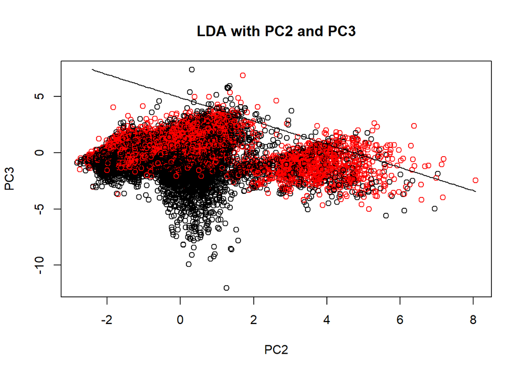

```r
# construct the LDA model
mylda6 <- lda(bank$y ~ PC2+PC3, data = pc.bc3.scores)

# draw discrimination line
np <- 300
nd.x <- seq(from = min(pc.bc3.scores$PC2), to = max(pc.bc3.scores$PC2), length.out = np)
nd.y <- seq(from = min(pc.bc3.scores$PC3), to = max(pc.bc3.scores$PC3), length.out = np)
nd <- expand.grid(PC2 = nd.x, PC3 = nd.y)

prd <- as.numeric(predict(mylda6, newdata = nd)$class)

plot(pc.bc3.scores[, 2:3], col = as.factor(bank$y), main="LDA with PC2 and PC3")
points(mylda6$means, pch = "+", cex = 2, col = c("black", "red"))
contour(x = nd.x, y = nd.y, z = matrix(prd, nrow = np, ncol = np),
                levels = c(1, 2), add = TRUE, drawlabels = FALSE)
```

### QDA with only the first 2 PCs as variables shows a nonlinear cutoff line below.

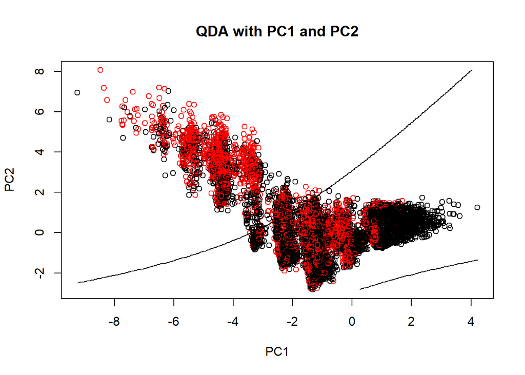

```r
# construct the QDA model
myqda <- qda(bank$y ~ PC1+PC2, data = pc.bc3.scores)

# draw discrimination line
np <- 300
nd.x <- seq(from = min(pc.bc3.scores$PC1), to = max(pc.bc3.scores$PC1), length.out = np)
nd.y <- seq(from = min(pc.bc3.scores$PC2), to = max(pc.bc3.scores$PC2), length.out = np)
nd <- expand.grid(PC1 = nd.x, PC2 = nd.y)

prd <- as.numeric(predict(myqda, newdata = nd)$class)

plot(pc.bc3.scores[, 1:2], col = as.factor(bank$y), main="QDA with PC1 and PC2")
points(myqda$means, pch = "+", cex = 2, col = c("black", "red"))
contour(x = nd.x, y = nd.y, z = matrix(prd, nrow = np, ncol = np),
                levels = c(1, 2), add = TRUE, drawlabels = FALSE)
```

### QDA with only PC2 and PC3 as variables shows a non-linear cutoff line below.

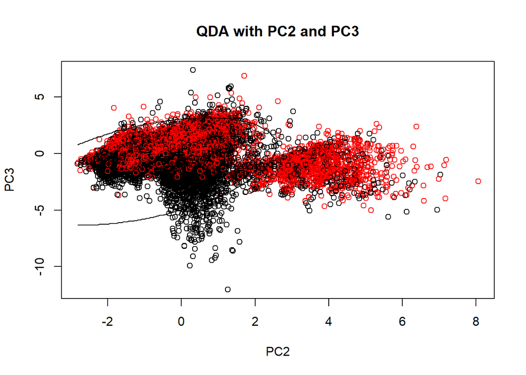

```r
# construct the QDA model
myqda2 <- qda(bank$y ~ PC2+PC3, data = pc.bc3.scores)

# draw discrimination line
np <- 300
nd.x <- seq(from = min(pc.bc3.scores$PC2), to = max(pc.bc3.scores$PC2), length.out = np)
nd.y <- seq(from = min(pc.bc3.scores$PC3), to = max(pc.bc3.scores$PC3), length.out = np)
nd <- expand.grid(PC2 = nd.x, PC3 = nd.y)

prd <- as.numeric(predict(myqda2, newdata = nd)$class)

plot(pc.bc3.scores[, 2:3], col = as.factor(bank$y), main="QDA with PC2 and PC3")
points(myqda2$means, pch = "+", cex = 2, col = c("black", "red"))
contour(x = nd.x, y = nd.y, z = matrix(prd, nrow = np, ncol = np),
                levels = c(1, 2), add = TRUE, drawlabels = FALSE)
```

```r
myqda3 <- qda(bank$y ~ PC1+PC2+PC3+PC4+PC5+PC6 , data = pc.bc3.scores)

x1=table(predict(myqda3, type="class")$class, bank$y)
x1
```

```
##
##          no   yes
##   no  34167  2174
##   yes  2381  2466
```

```r
#presicion
x1[1,1]/sum(x1[1,1:2])
```

```
## [1] 0.9401778
```

```r
#recall
x1[1,1]/sum(x1[1:2,1])
```

```
## [1] 0.9348528
```

```r
# F score

(2*(x1[1,1]/sum(x1[1,1:2])) * (x1[1,1]/sum(x1[1:2,1])))/(x1[1,1]/sum(x1[1,1:2])) + (x1[1,1]/sum(x1[1:2,1]))
```

```
## [1] 2.804558
```

```r
#Missclassification Error
ME1<-(x1[2,1]+x1[1,2])/dim(bank_con_select)[1]
ME1
```

```
## [1] 0.1105905
```

```r
#Calculating overall accuracy
1-ME1
```

```
## [1] 0.8894095
```